# **Addition Insights - Companies to Watch Newsletter**

August 9, 2022

## **Nansen**

**Company:** Nansen  
**Country (Operating):** 22 Sin Ming Lane, Suite 06-76, Midview City, Singapore, 573969, Singapore  
**Founded Date:** January 01, 2020  
**Homepage:** https://nansen.ai  
**Current Headcount:** 103  
**Lifetime Funding:** $88,200,000  
**Number of Funding Rounds:** 3  
**Investors:** Tiger Global Management, Volt Capital, Coinbase Ventures, Ameet Patel, Folius Ventures, Skyfall Ventures, Cristóbal Conde, Mechanism Capital, L1 Digital AG, Old Fashion Research, Coinbase, Mechanism Ventures, Sparq Ventures, Founder Friendly Labs, Robot Ventures, Amplify Partners, imToken Ventures, BitScale, QCP Capital, BR Capital, Accel, GIC, SCB 10X, Fabric VC, Andreessen Horowitz, Will Price, NULL, Anthony Yoon, Eric Conner, Sergei Chan, Kevin Hu, Spencer Noon, Nikolai Johan Heum, Nisa Amoils, Thuc Hoang  
**Most Recent Funding:** SERIES B - December 16, 2021  
**Sectors:** Financial Technology, Financial / Insurance Services, Blockchain / Crypto  
**Description:** Nansen is a blockchain analytics platform that enriches on-chain data with millions of wallet labels. Crypto investors use Nansen to discover opportunities, perform due diligence, and defend their portfolios with real-time alerts.

### **Headcount**

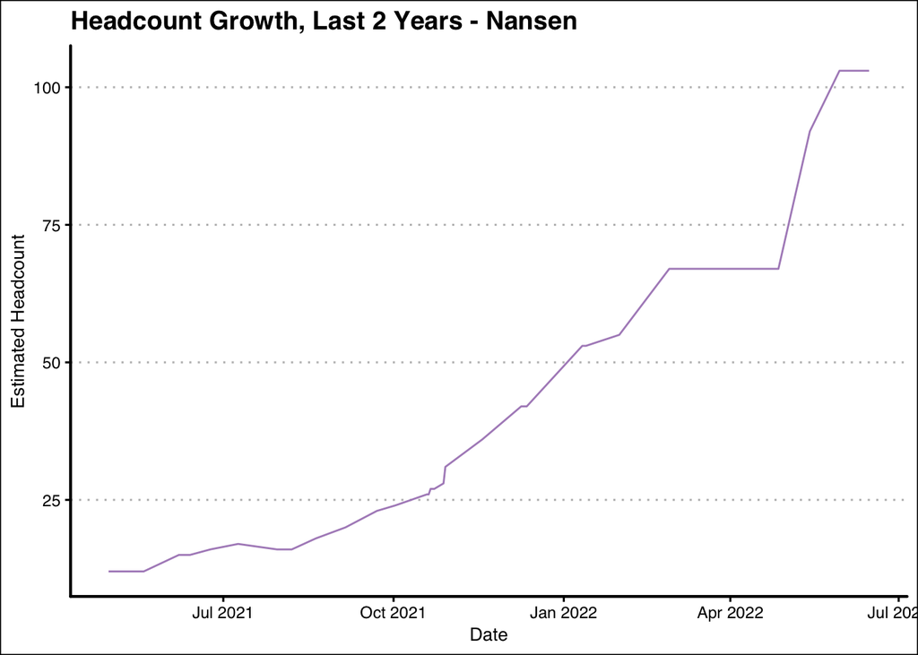

### **Buyer Intent (G2)**

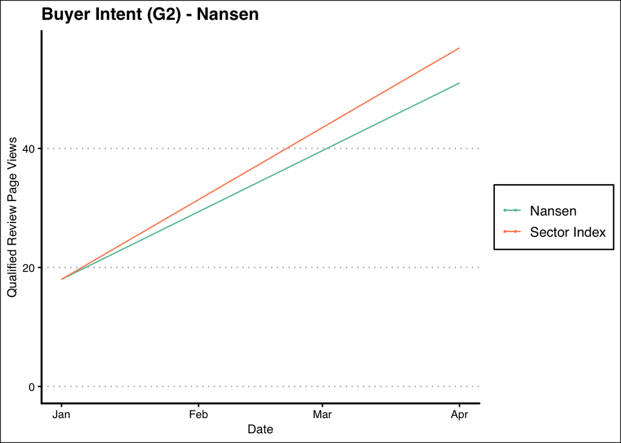

## **Lemon Cash**

**Company:** Lemon Cash  
**Country (Operating):** Paraguay 4747, 4to Blue, Capital Federal, Buenos Aires, 4747, Argentina  
**Founded Date:** January 01, 2019  
**Homepage:** https://lemon.me  
**Current Headcount:** 284  
**Lifetime Funding:** $16,300,000  
**Number of Funding Rounds:** 4  
**Investors:** Draper Associates, Draper Cygnus, Amagis Capital: Fin-Tech & Financial Advisory, Kingsway Capital, Coinbase, Sur Ventures, Borderless Capital, Cadenza Ventures, Grupo Supervielle, Valor Capital Group, Draper University, Mainstage Hub, Coinbase Ventures  
**Most Recent Funding:** SERIES A - July 27, 2021  
**Sectors:** Financial Technology, Financial / Insurance Services  
**Description:** The portal to the new economy

### **Headcount**

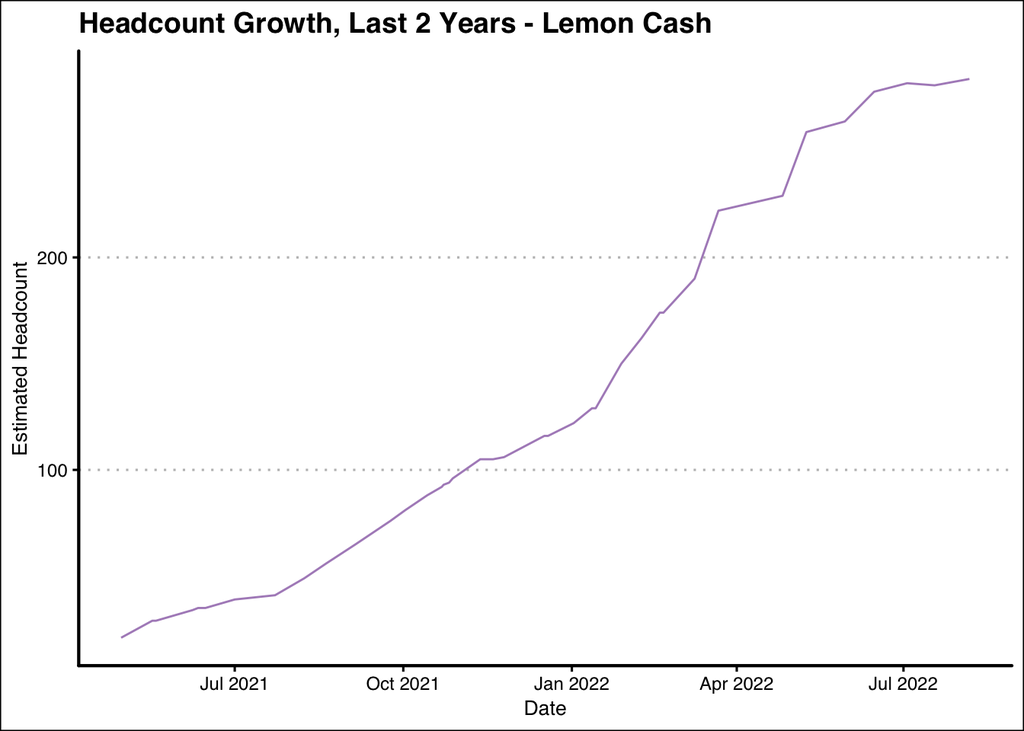

## **Everyrealm Inc.**

**Company:** Everyrealm Inc.  
**Country (Operating):** 510 Fifth Avenue 3rd Floor, New York, NY 10036, United States  
**Founded Date:** January 01, 2021  
**Homepage:** https://www.republicrealm.com  
**Current Headcount:** 56  
**Lifetime Funding:** $61,845,000  
**Number of Funding Rounds:** 4  
**Investors:** Pillar VC, Anthony Saleh, Galaxy Interactive, Griffin Gaming Partners, NGC Ventures, Coinbase Ventures, Andreessen Horowitz, Hashed  
**Most Recent Funding:** EARLY STAGE VC - May 04, 2022  
**Sectors:** Blockchain / Crypto  
**Description:** Investment and innovation company across the global metaverse & NFT ecosystem.

### **Headcount**

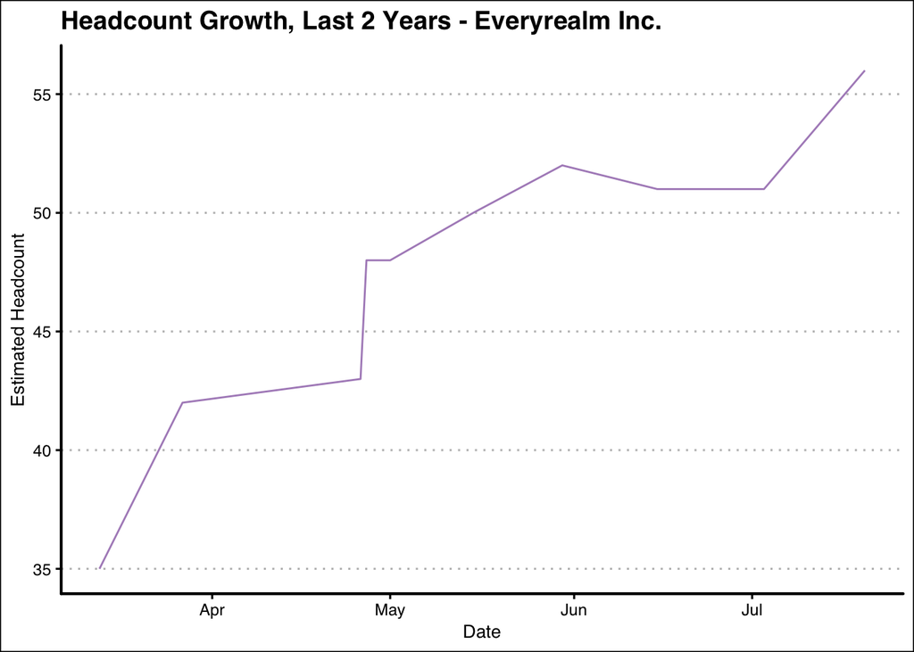

## **Autograph**

**Company:** Autograph  
**Country (Operating):** 12700 Chalon Road, Los Angeles, CA 90049, United States  
**Founded Date:** January 01, 2021  
**Homepage:** https://autograph.io  
**Current Headcount:** 133  
**Lifetime Funding:** $205,000,000  
**Number of Funding Rounds:** 2  
**Investors:** Gate Ventures, Cosmic Venture Partners, Balius Partners, Kleiner Perkins, Velvet Sea Ventures, Andreessen Horowitz, KRH (San Francisco), 01 Advisors, Haun Ventures, The Players’ Impact, Private Ventures Group (“PVG”), Nicole Quinn, Kathryn Haun  
**Most Recent Funding:** SERIES B - January 19, 2022  
**Sectors:** Blockchain / Crypto, Sports, Consumer Software Services, Media / News / Entertainment  
**Description:** Autograph is an NFT platform that brings together the most iconic brands and legendary names in sports, entertainment and culture to create unique digital collections and experiences for users around the world. Co-founded by Tom Brady and headquartered in Los Angeles, Autograph is ushering in a new era of collecting through a streamlined and inclusive process, authentic and creative products and exclusive partnerships.

### **Headcount**

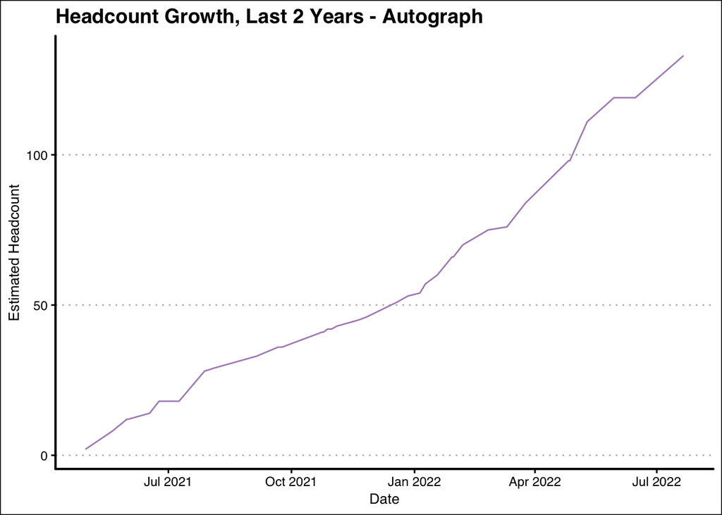

## **BitOasis**

**Company:** BitOasis  
**Country (Operating):** Building 07, Dubai Design District (D3), Dubai United Arab Emirates  
**Founded Date:** January 01, 2015  
**Homepage:** https://bitoasis.net  
**Current Headcount:** 195  
**Lifetime Funding:** $30,000,000  
**Number of Funding Rounds:** 3  
**Investors:** 76 Forward, Alameda Research, NXMH, Jabbar Internet Group, Merak Capital, Amazon Payment Services, KBBO Group, Finberg, Tamara Mellon, Jump Capital, Alameda Research Ventures, Saned Equity Partners, Integrated Networks - iNet , Digital Currency Group, Pantera Capital, 1776 Ventures, Global Founders Capital, Wamda Capital, JISR Investment Group , Omar Darwazah, Samih Toukan  
**Most Recent Funding:** SERIES B - October 06, 2021  
**Sectors:** Financial Technology, Financial / Insurance Services, AR / VR, Blockchain / Crypto  
**Description:** Based in Dubai, BitOasis is the MENA region’s largest cryptocurrency exchange for BitCoin and +65 cryptocurrencies. BitOasis clients can trade using local currencies like AED and SAR! 🚀 Founded in 2015, BitOasis is a pioneer of the region’s cryptocurrency ecosystem, serving as the go-to platform for first-time cryptocurrency buyers and professional traders alike. BitOasis is trusted by traders, institutions, and authorities across the region and the world. We aim to build the largest crypto-asset exchange and payments infrastructure platform in the Middle East and North Africa. As the leading crypto asset platform in the region, we continue setting the standard for the industry on regulatory compliance and providing the ability for our customers to buy, sell and trade crypto assets in a safe and regulated environment.

### **Headcount**

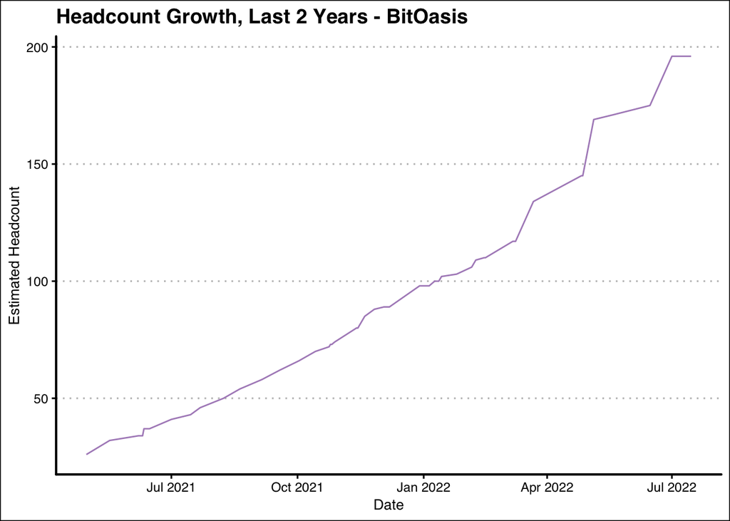

## **TRM Labs**

**Company:** TRM Labs  
**Country (Operating):** 450 Townsend Street, San Francisco, CA 94107, United States  
**Founded Date:** January 01, 2017  
**Homepage:** https://trmlabs.com  
**Current Headcount:** 136  
**Lifetime Funding:** $79,900,000  
**Number of Funding Rounds:** 5  
**Investors:** Tiger Global Management, Initialized Capital, NULL, American Express, Cap Table Coalition, Tapas Capital, SGH Capital, JPMorgan Chase & Co., Castle Island Ventures, Marshall Wace, Intersection Fintech Ventures, Frank Slootman, Tidepool Labs, Salesforce Ventures, Operator Partners, Citibank N.A. (California), Intersection Growth Partners, PayPal, Emilie Choi, Alumni Ventures, Bessemer Venture Partners, Jump Capital, PayPal Ventures, Quiet Capital, B Capital , VentureSouq, Y Combinator, The MBA Fund, Square, Blockchain Capital, Salesforce, Visa, Michael Scarpelli, Seth Weinstein  
**Most Recent Funding:** SERIES UNKNOWN - February 01, 2022  
**Sectors:** Financial Technology, Financial / Insurance Services, Data Analytics, Blockchain / Crypto  
**Description:** TRM Labs is a blockchain intelligence company that helps financial institutions, crypto businesses and government agencies detect and investigate crypto-related financial crime and fraud. Every day, we tackle challenges in data engineering, data science, and threat intelligence to advance our mission to build a safer financial system for billions of people. We have raised over $79M from JPMorgan Chase, Visa, Citi, PayPal, Block, Initialized Capital, Tiger Global, Bessemer, and Y Combinator.

### **Headcount**

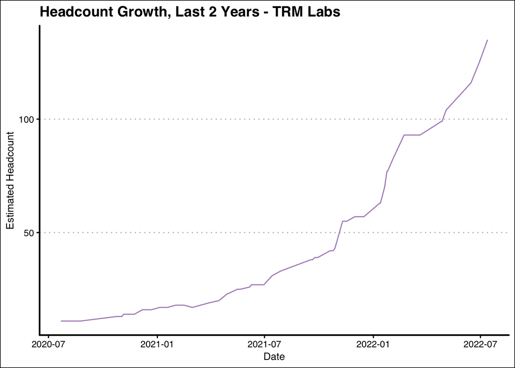

## **Mundi**

**Company:** Mundi  
**Country (Operating):** 19 West 24th Street, 10th Floor, New York, NY 10010, United States  
**Founded Date:** January 01, 2019  
**Homepage:** https://mundi.io  
**Current Headcount:** 195  
**Lifetime Funding:** $123,800,000  
**Number of Funding Rounds:** 2  
**Investors:** AlleyCorp, Andbank, Union Square Ventures, Silicon Valley Bank, Upper90, FJ Labs, Actyus, Operator Partners, Exor N.V., Base10 Partners, EXOR Seeds, Gilgamesh Ventures, Monex SAB de CV, Güimar Vaca Sittic  
**Most Recent Funding:** SERIES A - February 15, 2022  
**Sectors:** Financial Technology, Financial / Insurance Services  
**Description:** Mundi es la primera plataforma de servicios financieros para exportadores y agentes de carga. Exporta a todo el mundo y cobra tus facturas de contado fácil y digital.

### **Headcount**

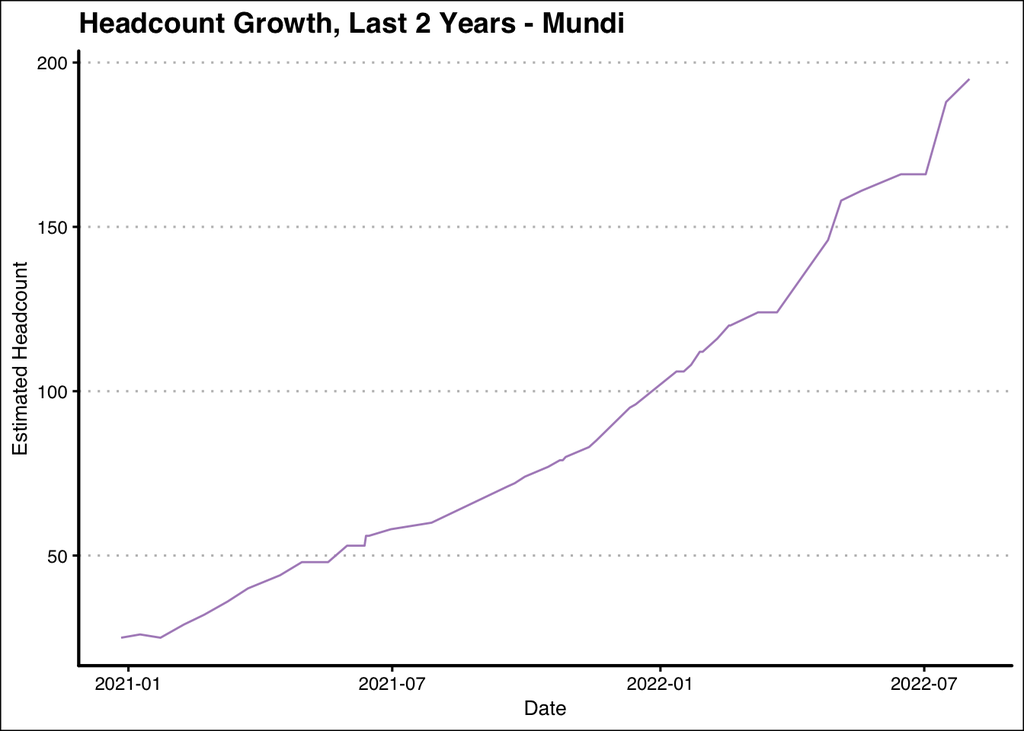